# Socioeconomic and Geographic Factors and the Relationship to Hospital Pricing

## Ryan Ripper 12/1/2021 Data Science I: Foundations PPOL564-01 - Fall 2021

# Problem Statement and Background

### 1. Can "Price Transparency" be used to study healthcare pricing?

### 2. Is healthcare pricing reflected in socioeconomic conditions?

### 3. Does heatlhcare pricing vary by region across the state of California?

# Considered Methods and Approaches

## Data Wrangling to Collect Data

### - Web Scraping to collect Hospital pricing information

### - Collecting income data (and other demographic information)

## Analyzing Data to Identify Relationships

### - Merging data on ZIP Code

### - Applying Machine Learning techniques and models to reveal connections between Socioeconomic Factors and Pricing

# Methods and Tools

## To address Web Scraping, employ the "Beautiful Soup" package in Python

## To address merging our data on ZIP Code and further data wrangling, employ the "Pandas" package in Python

## To address Machine Learning techniques and models, employ multiple models to determine which model best identifies any relationships

### 1. Naive Bayes Classifier

### 2. K-Nearest Neighbors Classifier

### 3. Decision Tree Classifier

### 4. Random Forest Classifier

# Preliminary Results and Conclusions

## Socioeconomic and Location Data:

### - Income by ZIP Code for 2019 - Households Mean Income (Dollars)

### - 33,120 Total ZIP Codes in the United States

### - 1,763 Total ZIP Codes in California

# Preliminary Results and Conclusions

## Hospital Data (American Hospital Directory):

### - California Hospitals with Beds - 408 Hospitals

### - California Hospitals without Beds - 70 Hospitals

# Preliminary Results and Conclusions

### Collection of Hospitals Across California

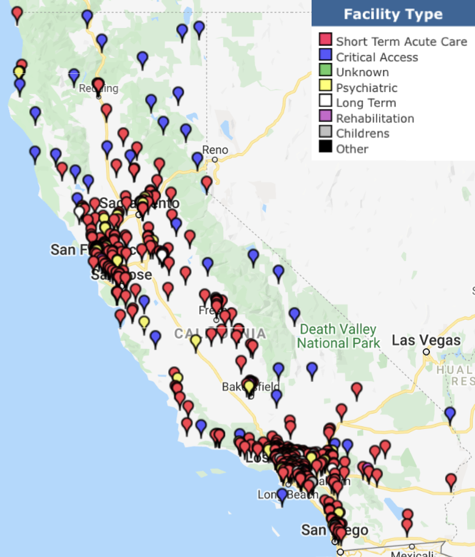

[https://www.ahd.com/list_cms.php?mstate%5B%5D=CA&listing=1&viewmap=1]

# Preliminary Results and Conclusions

### Further Collection of Data:

### - Individual Hospital Pricing - Shoppable Services

### - Additional Demographic Information

# Lessons Learned

### - Data collection and wrangling - Barriers to collect (i.e. reCAPTCHA, paywalls)

### - Data availability as published by hospitals to meet Price Transparency requirements

### - Variety of statistical and machine learning tools at our disposal, how to best apply these skills and techniques

# Works Cited

### 1: Centers for Medicare & Medicaid Services. (2020, October 29). Press release CMS completes historic price transparency initiative. CMS. Retrieved November 1, 2021, from https://www.cms.gov/newsroom/press-releases/cms-completes-historic-price-transparency-initiative.

### 2: Centers for Medicare & Medicaid Services. (2020, October 29). Press release CMS completes historic price transparency initiative. CMS. Retrieved November 1, 2021, from https://www.cms.gov/newsroom/press-releases/cms-completes-historic-price-transparency-initiative.

### 3: American Hospital Directory - information about hospitals from public and private data sources including MedPAR, OPPS, hospital cost reports, and other CMS files. (n.d.). Retrieved November 1, 2021, from https://www.ahd.com/.

### 4: Bureau, U. S. C. (2021, October 12). American Community Survey (ACS). Census.gov. Retrieved November 1, 2021, from https://www.census.gov/programs-surveys/acs.

### 5: CA.GOV (2019, October 23). County and Zip Code References. CA.GOV. Retrieved November 1, 2021 from https://data.ca.gov/dataset/county-and-zip-code-references